# Raport z analizy zmiany w rozmiarze wyławianego Śledzia Oceanicznego

Witold Kupś

24 listopad, 2019

# Abstrakt

Raport ten dotyczy analizy malejącej tendencji rozmiaru Śledzia Oceanicznego na przestrzeni ostatnich lat. Podejmuję tutaj próbę identyfikacji mających na to największy wpływ czynników na bazie zbioru ponad 52 tysięcy obserwacji zebranych w ciągu 60 lat. Analiza prowadzona jest bazując na podejściu zarówno czysto statystyczno-analitycznym z licznymi wizualizacjami, jak i przy wykorzystaniu kilku regresorów - Knn, Random Forest oraz Extreme Gradien Boosting.

# Wprowadzenie

Na przestrzeni ostatnich lat zauważono stopniowy spadek rozmiaru śledzia oceanicznego wyławianego w Europie. Do analizy sytuacji zebrano pomiary śledzi oraz ich środowiska w ostatnich 60 latach. Dane pochodzą z połowów komercyjnych jednostek. W ramach połowu jednej jednostki losowo wybierano od 50 do 100 sztuk trzyletnich śledzi; każdy z takich śledzi stanowi jedną obserwację.

### Inicjalizacja środowiska

```r
library(ggplot2)
library(dplyr)
library(DT)
library(GGally)
library(magick)
library(cowplot)
library(caret)
library(readxl)
library(xgboost)
library(randomForest)
# ustawmy seed'a dla randoma w celu powtarzalności wyników
set.seed(1234)
```

### Import danych

Dane znajdują się w pliku `sledzie.csv` załączonym w repozytorium. Opisy ich atrybutów można znaleźć w [treści zadania](http://www.cs.put.poznan.pl/alabijak/emd/projekt/projekt_analiza.html); dla wygody jednak zamieszczono go również poniżej:

Kolejne kolumny w zbiorze danych to:

- length: długość złowionego śledzia [cm];
- cfin1: dostępność planktonu [zagęszczenie Calanus finmarchicus gat. 1];
- cfin2: dostępność planktonu [zagęszczenie Calanus finmarchicus gat. 2];
- chel1: dostępność planktonu [zagęszczenie Calanus helgolandicus gat. 1];
- chel2: dostępność planktonu [zagęszczenie Calanus helgolandicus gat. 2];
- lcop1: dostępność planktonu [zagęszczenie widłonogów gat. 1];
- lcop2: dostępność planktonu [zagęszczenie widłonogów gat. 2];
- fbar: natężenie połowów w regionie [ułamek pozostawionego narybku];
- recr: roczny narybek [liczba śledzi];
- cumf: łączne roczne natężenie połowów w regionie [ułamek pozostawionego narybku];
- totaln: łączna liczba ryb złowionych w ramach połowu [liczba śledzi];
- sst: temperatura przy powierzchni wody [°C];
- sal: poziom zasolenia wody [Knudsen ppt];
- xmonth: miesiąc połowu [numer miesiąca];
- nao: oscylacja północnoatlantycka [mb].

Wiersze w zbiorze są uporządkowane chronologicznie.

```r
sourceDataFileName <- "sledzie.csv"
```

Dokonajmy wstępnego wczytania danych - pierwszych 100 wierszy w celu automatycznego określenia klasy oraz podglądu danych

```r
initialHerringData <- read.csv(sourceDataFileName, nrows = 100)
classes <- sapply(initialHerringData, class)
classes
```

```
        X    length     cfin1     cfin2     chel1     chel2     lcop1     lcop2      fbar      recr      cumf    totaln       sst       sal
"integer" "numeric"  "factor"  "factor"  "factor"  "factor"  "factor"  "factor" "numeric" "integer" "numeric" "numeric"  "factor" "numeric"
   xmonth       nao
"integer" "numeric"
```

Jak widać, większość danych została zakwalifikowana jako factor mimo, że z opisu wynika, że są to liczby. Wczytajmy zatem cały plik w odpowiednich klasach - wartości brakujące reprezentuje `?`, natomiast jako separator dziesiętny przyjmujemy kropkę `.`. Plik nie zawiera również komentarzy. Szybka analiza pliku pozwoliła również na identyfikację, że zbiór składa się z około 52.6 tys wierszy - informację tą wykorzystamy w celu przyśpieszenia importu. Pomińmy również pierwszą kolumnę stanowiącą o indeksie.

```r
classes <- c("NULL", rep(c("numeric"), 13), "factor", "numeric")
herringData <- read.csv(sourceDataFileName, comment.char = "", header=TRUE, colClasses = classes, nrows=52600, dec = ".", na.strings = c("?"))
```

# Omówienie danych

### Weryfikacja zbioru

Sprawdzmy czy rozmiary zbioru pokrywają się z oczekiwaniami

```r
dim(herringData)
```

```
[1] 52582    15
```

Wygląda na to, że dane zostały poprawnie wczytane. Zobaczmy więc z czym mamy do czynienia

```r
herringData
```

| length | cfin1 | cfin2 | chel1 | chel2 | lcop1 | lcop2 | fbar | recr | cumf | totaln | sst | sal | xmonth | nao |
| --- | --- | --- | --- | --- | --- | --- | --- | --- | --- | --- | --- | --- | --- | --- |
| 23.0 | 0.02778 | 0.27785 | 2.46875 | NA | 2.54787 | 26.35881 | 0.356 | 482831 | 0.3059879 | 267380.8 | 14.30693 | 35.51234 | 7 | 2.80 |
| 22.5 | 0.02778 | 0.27785 | 2.46875 | 21.43548 | 2.54787 | 26.35881 | 0.356 | 482831 | 0.3059879 | 267380.8 | 14.30693 | 35.51234 | 7 | 2.80 |
| 25.0 | 0.02778 | 0.27785 | 2.46875 | 21.43548 | 2.54787 | 26.35881 | 0.356 | 482831 | 0.3059879 | 267380.8 | 14.30693 | 35.51234 | 7 | 2.80 |
| 25.5 | 0.02778 | 0.27785 | 2.46875 | 21.43548 | 2.54787 | 26.35881 | 0.356 | 482831 | 0.3059879 | 267380.8 | 14.30693 | 35.51234 | 7 | 2.80 |
| 24.0 | 0.02778 | 0.27785 | 2.46875 | 21.43548 | 2.54787 | 26.35881 | 0.356 | 482831 | 0.3059879 | 267380.8 | 14.30693 | 35.51234 | 7 | 2.80 |
| 22.0 | 0.02778 | 0.27785 | 2.46875 | 21.43548 | 2.54787 | NA | 0.356 | 482831 | 0.3059879 | 267380.8 | 14.30693 | 35.51234 | 7 | 2.80 |
| 24.0 | 0.02778 | 0.27785 | 2.46875 | 21.43548 | 2.54787 | 26.35881 | 0.356 | 482831 | 0.3059879 | 267380.8 | 14.30693 | 35.51234 | 7 | 2.80 |
| 23.5 | 0.02778 | 0.27785 | 2.46875 | 21.43548 | 2.54787 | 26.35881 | 0.356 | 482831 | 0.3059879 | 267380.8 | 14.30693 | 35.51234 | 7 | 2.80 |
| 22.5 | 0.02778 | 0.27785 | 2.46875 | 21.43548 | 2.54787 | 26.35881 | 0.356 | 482831 | 0.3059879 | 267380.8 | 14.30693 | 35.51234 | 7 | 2.80 |
| 22.5 | 0.02778 | 0.27785 | 2.46875 | 21.43548 | 2.54787 | 26.35881 | 0.356 | 482831 | 0.3059879 | 267380.8 | 14.30693 | 35.51234 | 7 | 2.80 |

[output cut: 990 more lines]

### Analiza zbioru

Następnie przeprowadzmy krótkie podsumowanie

```r
summary(herringData)
```

```
     length         cfin1             cfin2             chel1            chel2            lcop1              lcop2             fbar
 Min.   :19.0   Min.   : 0.0000   Min.   : 0.0000   Min.   : 0.000   Min.   : 5.238   Min.   :  0.3074   Min.   : 7.849   Min.   :0.0680
 1st Qu.:24.0   1st Qu.: 0.0000   1st Qu.: 0.2778   1st Qu.: 2.469   1st Qu.:13.427   1st Qu.:  2.5479   1st Qu.:17.808   1st Qu.:0.2270
 Median :25.5   Median : 0.1111   Median : 0.7012   Median : 5.750   Median :21.673   Median :  7.0000   Median :24.859   Median :0.3320
 Mean   :25.3   Mean   : 0.4458   Mean   : 2.0248   Mean   :10.006   Mean   :21.221   Mean   : 12.8108   Mean   :28.419   Mean   :0.3304
 3rd Qu.:26.5   3rd Qu.: 0.3333   3rd Qu.: 1.7936   3rd Qu.:11.500   3rd Qu.:27.193   3rd Qu.: 21.2315   3rd Qu.:37.232   3rd Qu.:0.4560
 Max.   :32.5   Max.   :37.6667   Max.   :19.3958   Max.   :75.000   Max.   :57.706   Max.   :115.5833   Max.   :68.736   Max.   :0.8490
                NA's   :1581      NA's   :1536      NA's   :1555     NA's   :1556     NA's   :1653       NA's   :1591
      recr              cumf             totaln             sst             sal            xmonth           nao
 Min.   : 140515   Min.   :0.06833   Min.   : 144137   Min.   :12.77   Min.   :35.40   8      : 9920   Min.   :-4.89000
 1st Qu.: 360061   1st Qu.:0.14809   1st Qu.: 306068   1st Qu.:13.60   1st Qu.:35.51   10     : 7972   1st Qu.:-1.89000
 Median : 421391   Median :0.23191   Median : 539558   Median :13.86   Median :35.51   7      : 6922   Median : 0.20000
 Mean   : 520367   Mean   :0.22981   Mean   : 514973   Mean   :13.87   Mean   :35.51   9      : 5714   Mean   :-0.09236
 3rd Qu.: 724151   3rd Qu.:0.29803   3rd Qu.: 730351   3rd Qu.:14.16   3rd Qu.:35.52   6      : 4218   3rd Qu.: 1.63000
 Max.   :1565890   Max.   :0.39801   Max.   :1015595   Max.   :14.73   Max.   :35.61   5      : 3736   Max.   : 5.08000
                                                       NA's   :1584                    (Other):14100
```

Jak widać, śledzie mają długość w przedziale 19-32.5 cm, z medianą ustaloną dla wartości 25.5 cm, najwięcej śledzi wyławia się w sierpniu, październiku oraz lipcu. Można również stwierdzić, że liczba brakujących danych dla pól *cfin*, *chel1*, *lcop* oraz *sst* jest porównywalna; dla innych column wszystkie dane są określone. Spróbujmy więc usunąć te wiersze, które je zawierają

```r
dim(herringData %>% na.omit())
```

```
[1] 42488    15
```

Zostało usuniętych około 10 tysięcy przykładów; nie jest to więc rozwiązanie, jakiego szukamy. Możemy zastąpić wartości brakujące średnią.

```r
naMeanHerringData <- herringData %>%
  mutate(
    cfin1 = ifelse(is.na(cfin1), mean(cfin1, na.rm=TRUE), cfin1),
    cfin2 = ifelse(is.na(cfin2), mean(cfin2, na.rm=TRUE), cfin2),
    chel1 = ifelse(is.na(chel1), mean(chel1, na.rm=TRUE), chel1),
    chel2 = ifelse(is.na(chel2), mean(chel2, na.rm=TRUE), chel2),
    lcop1 = ifelse(is.na(lcop1), mean(lcop1, na.rm=TRUE), lcop1),
    lcop2 = ifelse(is.na(lcop2), mean(lcop2, na.rm=TRUE), lcop2),
    sst = ifelse(is.na(sst), mean(sst, na.rm=TRUE), sst)
  )
```

```r
summary(naMeanHerringData)
```

```
     length         cfin1             cfin2             chel1            chel2            lcop1              lcop2             fbar
 Min.   :19.0   Min.   : 0.0000   Min.   : 0.0000   Min.   : 0.000   Min.   : 5.238   Min.   :  0.3074   Min.   : 7.849   Min.   :0.0680
 1st Qu.:24.0   1st Qu.: 0.0000   1st Qu.: 0.2778   1st Qu.: 2.469   1st Qu.:13.589   1st Qu.:  2.5479   1st Qu.:17.808   1st Qu.:0.2270
 Median :25.5   Median : 0.1333   Median : 0.7012   Median : 6.083   Median :21.435   Median :  7.1229   Median :25.338   Median :0.3320
 Mean   :25.3   Mean   : 0.4458   Mean   : 2.0248   Mean   :10.006   Mean   :21.221   Mean   : 12.8108   Mean   :28.419   Mean   :0.3304
 3rd Qu.:26.5   3rd Qu.: 0.3603   3rd Qu.: 1.9973   3rd Qu.:11.500   3rd Qu.:27.193   3rd Qu.: 21.2315   3rd Qu.:37.232   3rd Qu.:0.4560
 Max.   :32.5   Max.   :37.6667   Max.   :19.3958   Max.   :75.000   Max.   :57.706   Max.   :115.5833   Max.   :68.736   Max.   :0.8490

      recr              cumf             totaln             sst             sal            xmonth           nao
 Min.   : 140515   Min.   :0.06833   Min.   : 144137   Min.   :12.77   Min.   :35.40   8      : 9920   Min.   :-4.89000
 1st Qu.: 360061   1st Qu.:0.14809   1st Qu.: 306068   1st Qu.:13.63   1st Qu.:35.51   10     : 7972   1st Qu.:-1.89000
 Median : 421391   Median :0.23191   Median : 539558   Median :13.86   Median :35.51   7      : 6922   Median : 0.20000
 Mean   : 520367   Mean   :0.22981   Mean   : 514973   Mean   :13.87   Mean   :35.51   9      : 5714   Mean   :-0.09236
 3rd Qu.: 724151   3rd Qu.:0.29803   3rd Qu.: 730351   3rd Qu.:14.16   3rd Qu.:35.52   6      : 4218   3rd Qu.: 1.63000
 Max.   :1565890   Max.   :0.39801   Max.   :1015595   Max.   :14.73   Max.   :35.61   5      : 3736   Max.   : 5.08000
                                                                                       (Other):14100
```

Zostańmy więc z tym rozwiązaniem, chociaż prawdopodobnie dobrze byłoby brać średnią z wiersza wcześniej i później, jednak niesie to ze sobą również inne problemy.

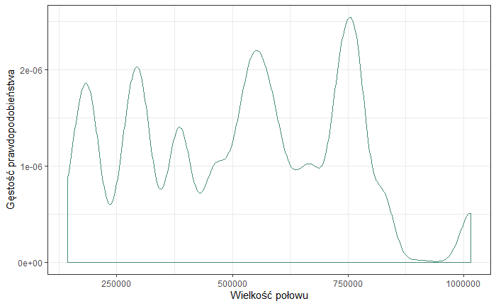

```r
  ggplot(data=naMeanHerringData, aes(x=totaln)) +
  geom_density(color = "aquamarine4", lwd = 0.7) +
  labs(x = "Wielkość połowu", y = "Gęstość prawdopodobieństwa") +
  theme_bw()
```

Niekoniecznie - nie przypomina on żadnego z popularnych rozkładów.

### Weryfikacja tendencji

Mamy za zadanie zweryfikować, czy przez ostatnie kilka lat rozmiar śledzia spadł. Przydatny może okazać sie więc wykres prezentujący średni rozmiar na rok. Jest jednak jeden problem - w danych mamy jedynie miesiąc połowu, informację o tym, że są to dane chronologicznie posortowane oraz pochodzą z ostatnich 60 lat. Należy więc w miarę możliwości dodać rok do danych bazując na tych informacjach.

Dane są chronologiczne, także powinniśmy być w stanie wywnioskować rok na podstawie zmiany miesiąca na mniejszy

```r
evaluateYearByMonthChange <- function(fishing) {
  curYear <- 0
  recentMonth <- 0
  l <- lapply(fishing, function(v) {
    v<- as.integer(v)
    if (v < recentMonth)
      curYear <<- curYear + 1
    recentMonth <<- v
    curYear
  })
  unlist(l)
}

herringDataWithYearByMonthChange <- mutate(naMeanHerringData, year=evaluateYearByMonthChange(xmonth))
herringDataWithYearByMonthChange
```

| length | cfin1 | cfin2 | chel1 | chel2 | lcop1 | lcop2 | fbar | recr | cumf | totaln | sst | sal | xmonth | nao | year |
| --- | --- | --- | --- | --- | --- | --- | --- | --- | --- | --- | --- | --- | --- | --- | --- |
| 23.0 | 0.027780 | 0.277850 | 2.46875 | 21.22108 | 2.54787 | 26.35881 | 0.356 | 482831 | 0.3059879 | 267380.8 | 14.30693 | 35.51234 | 7 | 2.80 | 0 |
| 22.5 | 0.027780 | 0.277850 | 2.46875 | 21.43548 | 2.54787 | 26.35881 | 0.356 | 482831 | 0.3059879 | 267380.8 | 14.30693 | 35.51234 | 7 | 2.80 | 0 |
| 25.0 | 0.027780 | 0.277850 | 2.46875 | 21.43548 | 2.54787 | 26.35881 | 0.356 | 482831 | 0.3059879 | 267380.8 | 14.30693 | 35.51234 | 7 | 2.80 | 0 |
| 25.5 | 0.027780 | 0.277850 | 2.46875 | 21.43548 | 2.54787 | 26.35881 | 0.356 | 482831 | 0.3059879 | 267380.8 | 14.30693 | 35.51234 | 7 | 2.80 | 0 |
| 24.0 | 0.027780 | 0.277850 | 2.46875 | 21.43548 | 2.54787 | 26.35881 | 0.356 | 482831 | 0.3059879 | 267380.8 | 14.30693 | 35.51234 | 7 | 2.80 | 0 |
| 22.0 | 0.027780 | 0.277850 | 2.46875 | 21.43548 | 2.54787 | 28.41883 | 0.356 | 482831 | 0.3059879 | 267380.8 | 14.30693 | 35.51234 | 7 | 2.80 | 0 |
| 24.0 | 0.027780 | 0.277850 | 2.46875 | 21.43548 | 2.54787 | 26.35881 | 0.356 | 482831 | 0.3059879 | 267380.8 | 14.30693 | 35.51234 | 7 | 2.80 | 0 |
| 23.5 | 0.027780 | 0.277850 | 2.46875 | 21.43548 | 2.54787 | 26.35881 | 0.356 | 482831 | 0.3059879 | 267380.8 | 14.30693 | 35.51234 | 7 | 2.80 | 0 |
| 22.5 | 0.027780 | 0.277850 | 2.46875 | 21.43548 | 2.54787 | 26.35881 | 0.356 | 482831 | 0.3059879 | 267380.8 | 14.30693 | 35.51234 | 7 | 2.80 | 0 |
| 22.5 | 0.027780 | 0.277850 | 2.46875 | 21.43548 | 2.54787 | 26.35881 | 0.356 | 482831 | 0.3059879 | 267380.8 | 14.30693 | 35.51234 | 7 | 2.80 | 0 |

[output cut: 990 more lines]

Pogrupujmy je po roku dzięki funkcji

```r
getSummaryFuncions <- function() {
  funs(mean = mean(., na.rm=TRUE), min = mean - sd(., na.rm= TRUE), max = mean + sd(., na.rm= TRUE))
}

statsInYear <- function(dataWithYear, var) {
  dataWithYear %>%
    group_by(year) %>%
    summarise_at(vars(var), getSummaryFuncions())
}


meanLengthInYearChart <- function(dataWithYear, var = "length", title = "Długość śledzia", color = "aquamarine4", fill = "darkseagreen3") {
  meanPerYear <- statsInYear(dataWithYear, var)
  ggplot(data=meanPerYear, aes(x = year, y = mean)) +
    geom_ribbon(aes(ymin = min, ymax = max), alpha = 0.5, fill = fill, color = "transparent") +
      geom_line(color = color, lwd = 0.7) +
    labs(x = "Rok", y = title) +
  theme_bw()
}
```

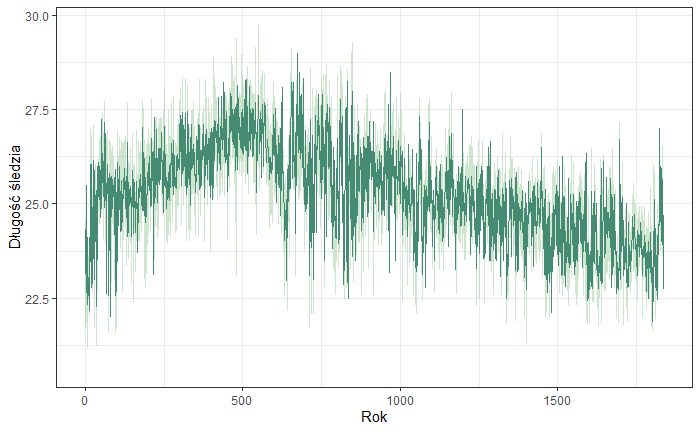

```r
meanLengthInYearChart(herringDataWithYearByMonthChange)
```

Można dostrzec malejącą tendencję w przez “ostatnie lata” (łącznie prawie 2000 zamiast 60), jednak założenie o chronologii jak widać okazało się błędne - przynajmniej w zakresie kolejności miesięcy. Jest również pole `recr` mówiące o połowie w roku. Widzimy, że występuje pewna powtarzalność, więc jeśli dane byłyby chronologiczne, a zarazem ich rozpiętość jest całkiem spora, powinno to pozwolić na zgrupowanie.

```r
evaluateYear <- function(fishing) {
  curYear <- 0
  recentYearFishing <- 0
  l <- lapply(fishing, function(v) {
    if (v != recentYearFishing)
      curYear <<- curYear + 1
    recentYearFishing <<- v
    curYear
  })
  unlist(l)
}

herringDataWithYearByRecr <- mutate(naMeanHerringData, year=evaluateYear(recr))
herringDataWithYearByRecr
```

| length | cfin1 | cfin2 | chel1 | chel2 | lcop1 | lcop2 | fbar | recr | cumf | totaln | sst | sal | xmonth | nao | year |
| --- | --- | --- | --- | --- | --- | --- | --- | --- | --- | --- | --- | --- | --- | --- | --- |
| 23.0 | 0.027780 | 0.277850 | 2.46875 | 21.22108 | 2.54787 | 26.35881 | 0.356 | 482831 | 0.3059879 | 267380.8 | 14.30693 | 35.51234 | 7 | 2.80 | 1 |
| 22.5 | 0.027780 | 0.277850 | 2.46875 | 21.43548 | 2.54787 | 26.35881 | 0.356 | 482831 | 0.3059879 | 267380.8 | 14.30693 | 35.51234 | 7 | 2.80 | 1 |
| 25.0 | 0.027780 | 0.277850 | 2.46875 | 21.43548 | 2.54787 | 26.35881 | 0.356 | 482831 | 0.3059879 | 267380.8 | 14.30693 | 35.51234 | 7 | 2.80 | 1 |
| 25.5 | 0.027780 | 0.277850 | 2.46875 | 21.43548 | 2.54787 | 26.35881 | 0.356 | 482831 | 0.3059879 | 267380.8 | 14.30693 | 35.51234 | 7 | 2.80 | 1 |
| 24.0 | 0.027780 | 0.277850 | 2.46875 | 21.43548 | 2.54787 | 26.35881 | 0.356 | 482831 | 0.3059879 | 267380.8 | 14.30693 | 35.51234 | 7 | 2.80 | 1 |
| 22.0 | 0.027780 | 0.277850 | 2.46875 | 21.43548 | 2.54787 | 28.41883 | 0.356 | 482831 | 0.3059879 | 267380.8 | 14.30693 | 35.51234 | 7 | 2.80 | 1 |
| 24.0 | 0.027780 | 0.277850 | 2.46875 | 21.43548 | 2.54787 | 26.35881 | 0.356 | 482831 | 0.3059879 | 267380.8 | 14.30693 | 35.51234 | 7 | 2.80 | 1 |
| 23.5 | 0.027780 | 0.277850 | 2.46875 | 21.43548 | 2.54787 | 26.35881 | 0.356 | 482831 | 0.3059879 | 267380.8 | 14.30693 | 35.51234 | 7 | 2.80 | 1 |
| 22.5 | 0.027780 | 0.277850 | 2.46875 | 21.43548 | 2.54787 | 26.35881 | 0.356 | 482831 | 0.3059879 | 267380.8 | 14.30693 | 35.51234 | 7 | 2.80 | 1 |
| 22.5 | 0.027780 | 0.277850 | 2.46875 | 21.43548 | 2.54787 | 26.35881 | 0.356 | 482831 | 0.3059879 | 267380.8 | 14.30693 | 35.51234 | 7 | 2.80 | 1 |

[output cut: 990 more lines]

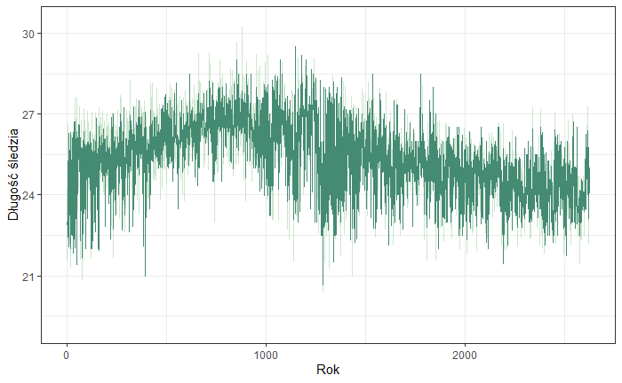

```r
meanLengthInYearChart(herringDataWithYearByRecr)
```

Niestety, ponownie porażka. W takim razie może po prostu sprawdzmy czy występuje trend w czystych danych:

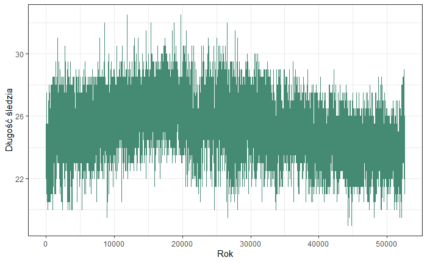

```r
ggplot(naMeanHerringData, aes(x=as.numeric(row.names(naMeanHerringData)), y=naMeanHerringData$length)) +
  geom_line(color = "aquamarine4") +
  labs(x = "Rok", y = "Długość śledzia") +
  theme_bw()
```

Dobrze, jakąś zależność widać - może aby być jej pewnym uśrednijmy dane licząc na prawo wielkich liczb oraz wiedzę o tym, że mamy do czynienia z danymi z okresu 60 lat

```r
expectedYears <- 60
expectedRowsPerYears <- nrow(naMeanHerringData) %/% 60
herringDataWithYearByPeriod <- naMeanHerringData %>%
  mutate(year = 1:n() %/% expectedRowsPerYears)
herringDataWithYearByPeriod
```

| length | cfin1 | cfin2 | chel1 | chel2 | lcop1 | lcop2 | fbar | recr | cumf | totaln | sst | sal | xmonth | nao | year |
| --- | --- | --- | --- | --- | --- | --- | --- | --- | --- | --- | --- | --- | --- | --- | --- |
| 23.0 | 0.027780 | 0.277850 | 2.46875 | 21.22108 | 2.54787 | 26.35881 | 0.356 | 482831 | 0.3059879 | 267380.8 | 14.30693 | 35.51234 | 7 | 2.80 | 0 |
| 22.5 | 0.027780 | 0.277850 | 2.46875 | 21.43548 | 2.54787 | 26.35881 | 0.356 | 482831 | 0.3059879 | 267380.8 | 14.30693 | 35.51234 | 7 | 2.80 | 0 |
| 25.0 | 0.027780 | 0.277850 | 2.46875 | 21.43548 | 2.54787 | 26.35881 | 0.356 | 482831 | 0.3059879 | 267380.8 | 14.30693 | 35.51234 | 7 | 2.80 | 0 |
| 25.5 | 0.027780 | 0.277850 | 2.46875 | 21.43548 | 2.54787 | 26.35881 | 0.356 | 482831 | 0.3059879 | 267380.8 | 14.30693 | 35.51234 | 7 | 2.80 | 0 |
| 24.0 | 0.027780 | 0.277850 | 2.46875 | 21.43548 | 2.54787 | 26.35881 | 0.356 | 482831 | 0.3059879 | 267380.8 | 14.30693 | 35.51234 | 7 | 2.80 | 0 |
| 22.0 | 0.027780 | 0.277850 | 2.46875 | 21.43548 | 2.54787 | 28.41883 | 0.356 | 482831 | 0.3059879 | 267380.8 | 14.30693 | 35.51234 | 7 | 2.80 | 0 |
| 24.0 | 0.027780 | 0.277850 | 2.46875 | 21.43548 | 2.54787 | 26.35881 | 0.356 | 482831 | 0.3059879 | 267380.8 | 14.30693 | 35.51234 | 7 | 2.80 | 0 |
| 23.5 | 0.027780 | 0.277850 | 2.46875 | 21.43548 | 2.54787 | 26.35881 | 0.356 | 482831 | 0.3059879 | 267380.8 | 14.30693 | 35.51234 | 7 | 2.80 | 0 |
| 22.5 | 0.027780 | 0.277850 | 2.46875 | 21.43548 | 2.54787 | 26.35881 | 0.356 | 482831 | 0.3059879 | 267380.8 | 14.30693 | 35.51234 | 7 | 2.80 | 0 |
| 22.5 | 0.027780 | 0.277850 | 2.46875 | 21.43548 | 2.54787 | 26.35881 | 0.356 | 482831 | 0.3059879 | 267380.8 | 14.30693 | 35.51234 | 7 | 2.80 | 0 |

[output cut: 990 more lines]

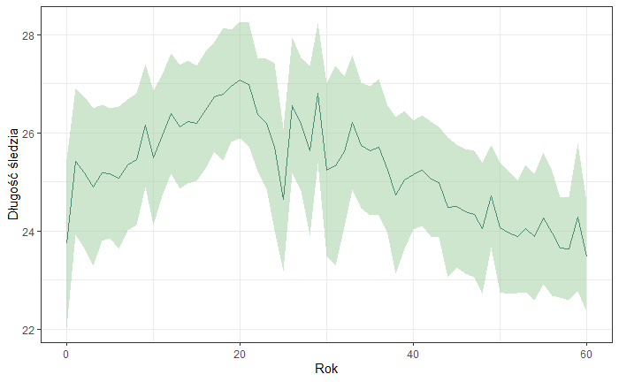

```r
meanLengthInYearChart(herringDataWithYearByPeriod)
```

Widzimy więc, że w rzeczywistości istnieje istotny spadek średniej długości śledzia na przełomie lat. Możemy to zwizualizować.

```r
img <- image_read("herring.svg")
img <- image_trim(img)
heightRatio <- 110/475
maxWidth = 542
maxHeight <- heightRatio * maxWidth
herringsImgs <- statsInYear(herringDataWithYearByPeriod, "length") %>%
  apply(1, function(r) {
    newWidth <- round((r[[2]] - 10) * 30)
    widthDif <- round((maxWidth - newWidth)/2)
    heightDif <- round(widthDif * heightRatio)
    image_scale(img, newWidth) %>%
        image_border("white", paste(c(widthDif, "x", heightDif), collapse = "")) %>%
        image_annotate(paste(c("Rok: ", r[[1]]), collapse = ""), color = "black", size = 30)
  })
frames <- image_morph(image_join(herringsImgs), frames = 1)
anim <- image_animate(frames, fps = 10)
image_write(anim, "herring.gif")
```

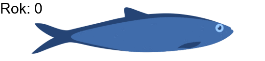

### Analiza statystyczna

Zidentyfikujmy możliwe powody takiego zachowania wyznaczając macierz korelacji.

Wcześniej jednak należy zmienić typ kolumny `xmonth` z powrotem na liczbę i przygotować dane.

```r
herringDataWithNumericMonth = mutate(naMeanHerringData, xmonth = as.numeric(xmonth))
```

Zobaczmy możliwe zależności w bardziej przyjaznej formie

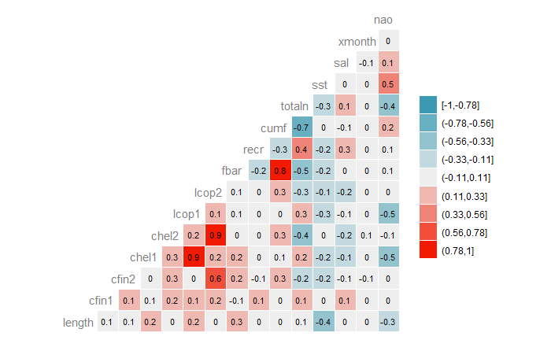

```r
ggcorr(
  herringDataWithNumericMonth,
  nbreaks = 9,
  label = TRUE,
  label_size = 3,
  color = "grey50",
  layout.exp = 1,
  hjust = 0.75,
)
```

Widać dużą korelację pomiędzy parami `chel1` - `lcop1`, `chel2` - `lcop2`, `fbar` - `cumf`, `cfin2` - `lcop2` oraz `cumf` - `totaln`. Na samą długość w największym stopniu wpływa `sst`, `nao` oraz `fbar`. Widzimy że `lcop1`, `lcop2` oraz `cumf` mogą zostać pominięte w procesie dalszej analizy jako redundantne. Teoretycznie moglibyśmy również usunąć miesiąc ze względu na powtarzalność, ale może mieć on wpływ na cykl rozwojowy, więc pozostawmy go póki co.

```r
filteredHerringDataWithNumericMonth <- select(herringDataWithNumericMonth, -c(lcop1, lcop2, cumf))
```

Zobaczmy jeszcze jak przebiega zależność pomiędzy najbardziej obiecującymi zmiennymi na długość; kolorami wyróżniono również miesiące

```r
numericChart <- function(colName) {
  ggplot(naMeanHerringData, aes(x = length, y = naMeanHerringData[[colName]], color=xmonth)) +
    geom_jitter(size = 1.5, stat = "identity") +
    labs(x = "Długość", y = colName) +
    theme_bw()
}
```

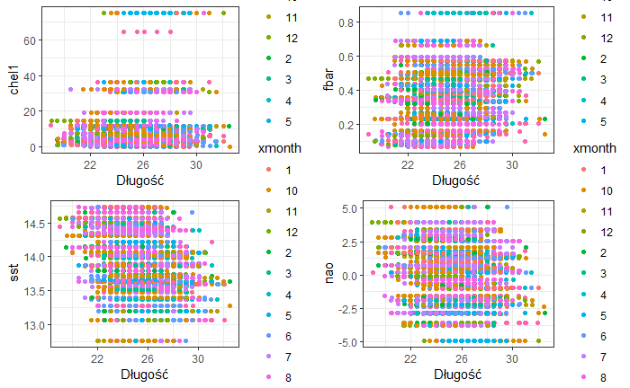

```r
plot_grid(
  numericChart("chel1"),
  numericChart("fbar"),
  numericChart("sst"),
  numericChart("nao")
)
```

Powiązanie rosnącego `sst` oraz `nao` jasno wpływa negatywnie na długość, przy `fbar` również można dostrzec pozywytną korelację.

Sprawdzmy również zależność pomiędzy miesiącem połowu a długością; w macierzy korelacji nie mogliśmy tego do końca zweryfikować, jednak ze względu na cykliczność było to również utrudnione (miesiąc w tym wypadku jest sztucznie liczbą).

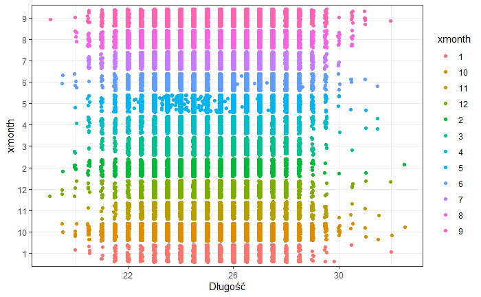

```r
numericChart("xmonth")
```

Wydaje się, że nie ma żadnej znaczącej zależności pomiędzy miesiącem połowu a długością śledzia

# Predykcja rozmiaru śledzia

W celu predykcji wykorzystajmy bibliotekę `caret`. Podzielmy najpierw zbiór danych na uczące i testowe w relacji 70:30

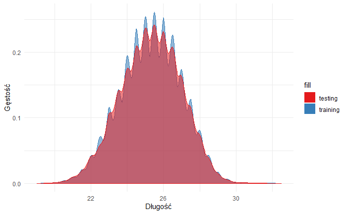

```r
regHerringData <- filteredHerringDataWithNumericMonth
inTrain <- createDataPartition(regHerringData$length, p=0.7, list=FALSE)
training <- regHerringData[inTrain,]
testing <- regHerringData[-inTrain,]

ggplot(mapping=aes(alpha=0.2)) +
 geom_density(aes(length, fill="training", color="training"), training) +
 geom_density(aes(length, fill="testing", color="testing"), testing) +
 theme_minimal() +
  xlab("Długość") +
  ylab("Gęstość") +
  scale_fill_brewer(palette="Set1") +
  scale_color_brewer(palette="Set1") +
  guides(color = FALSE, alpha = FALSE, fill=guide_legend(override.aes = list(color = NA)))
```

Widzimy że zbiory dobrze się pokrywają. Czas przygotować dane

```r
X_train = select(training, -length)
y_train = training$length
X_test = select(testing, -length)
y_test = testing$length
```

Przygotujmy 5-krotną walidację krzyżową (jedynie 5 ze względu na wiele metod oraz długi czas niektórych z nich a także małe różnice w rezultatach)

```r
trcontrol = trainControl(
  method = "cv",
  number = 5,
  allowParallel = TRUE,
  verboseIter = FALSE,
  returnData = FALSE
)
```

oraz metody pomocnicze

```r
evaluateStats <- function(model) {
  predicted = predict(model, X_test)
  residuals = y_test - predicted

  RMSE <- round(sqrt(mean(residuals^2)), 3)

  y_testMean = mean(y_test)
  totalSS =  sum((y_test - y_testMean)^2 )
  residualSS =  sum(residuals^2)
  rSquare  =  round(1 - (residualSS/totalSS), 3)

  list(RMSE = RMSE, rSquare = rSquare)
}
```

```r
predictionChart <- function(model) {
  predicted = predict(model, X_test)
  mergedResults = as.data.frame(cbind(predicted = predicted, observed = y_test))
  # Plot predictions vs test data
  ggplot(mergedResults, aes(y = predicted, x = observed)) +
    geom_point(color = "darkred", alpha = 0.5) +
    geom_smooth(method=lm) +
    ylab("Przewidziana długość") +
    xlab("Rzeczywista długość") +
    theme(
      axis.text.y = element_text(size=12), axis.text.x = element_text(size=12,hjust=.5),
      axis.title.x = element_text(size=14), axis.title.y = element_text(size=14)
    )
}
```

```r
importancePlot <- function(model) ggplot(varImp(model))
```

W dalszej części dokonamy predykcji za pomocą regresji kilkoma regresorami, jednak ich porównanie oraz wnioski zostawimy na koniec

## Knn

```r
knnGrid <- expand.grid(k = seq(1, 31, by = 2))
```

```r
knnModel <- train(
  X_train, y_train,
  method = "knn",
  trControl = trcontrol,
  tuneGrid = knnGrid
)
```

### Najlepsze parametry

```r
knnModel$bestTune
```

|  | k |
| --- | --- |
| 5 | 9 |

### Ewaluacja modelu

Błąd średniokwadratowy dla danych testowych oraz wspołczynnik determinacji

```r
knnStats <- evaluateStats(knnModel)
knnStats
```

```
$RMSE
[1] 1.148

$rSquare
[1] 0.516
```

### Weryfikacja predykcji

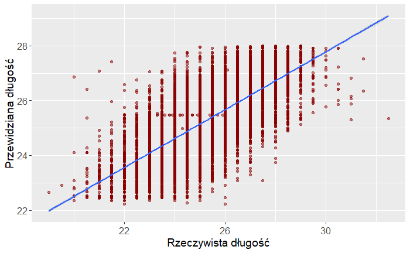

```r
predictionChart(knnModel)
```

## Knn + preprocessing

```r
knnPreModel <- train(
  X_train, y_train,
  method = "knn",
  trControl = trcontrol,
  tuneGrid = knnGrid,
  preProcess = c("center", "scale")
)
```

### Najlepsze parametry

```r
knnPreModel$bestTune
```

|  | k |
| --- | --- |
| 6 | 11 |

### Ewaluacja modelu

Błąd średniokwadratowy dla danych testowych oraz wspołczynnik determinacji

```r
knnPreStats <- evaluateStats(knnPreModel)
knnPreStats
```

```
$RMSE
[1] 1.149

$rSquare
[1] 0.515
```

### Weryfikacja predykcji

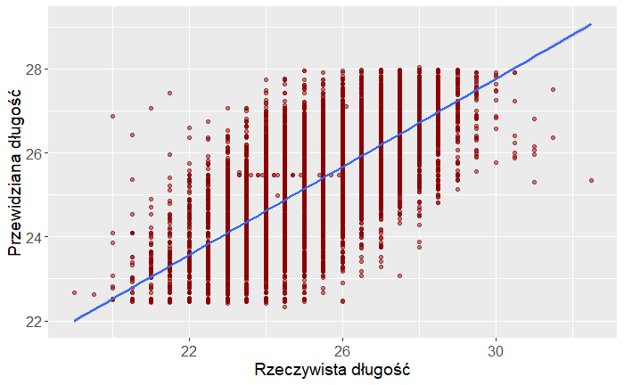

```r
predictionChart(knnPreModel)
```

## Random Forest

```r
rfGrid <- expand.grid(.mtry=sqrt(ncol(X_train)))
```

```r
rfModel <- train(
  X_train, y_train,
  method = "rf",
  trControl = trcontrol,
  tuneGrid = rfGrid,
  importance = TRUE
)
```

### Najlepsze parametry

```r
rfModel$bestTune
```

|  | mtry |
| --- | --- |
| 1 | 3.316625 |

### Ewaluacja modelu

Błąd średniokwadratowy dla danych testowych oraz wspołczynnik determinacji

```r
rfStats <- evaluateStats(rfModel)
rfStats
```

```
$RMSE
[1] 1.15

$rSquare
[1] 0.514
```

### Weryfikacja predykcji

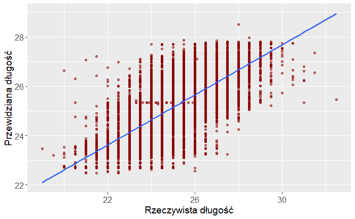

```r
predictionChart(rfModel)
```

### Ważność parametrów

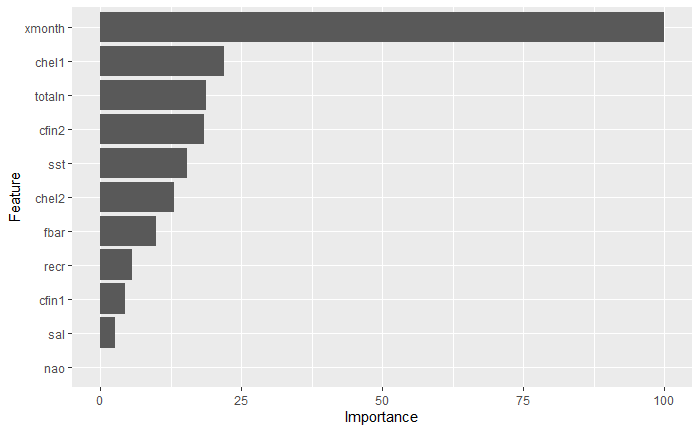

```r
importancePlot(rfModel)
```

Widać, że według *Random Forest* najważniejszym parametrem jest `xmonth`; jest on kilkukrotnie ważniejszy od drugiego w kolejności - `chel1`.

## Extreme Gradient Boosting

Poniższe wartości (`eta`, `gamma`, `min_child_weight` oraz `subsample`) są wartościami domyślnymi w adekwatnej metodzie w [`sklearn`](https://xgboost.readthedocs.io/en/latest/python/python_api.html).

```r
xgbGrid <- expand.grid(
    nrounds = c(100,200),
    max_depth = c(10, 15, 20, 25),
    colsample_bytree = seq(0.5, 0.9, length.out = 5),
    eta = 0.1,
    gamma=0,
    min_child_weight = 1,
    subsample = 1
  )
```

```r
xgbModel <- train(
  X_train, y_train,
  trControl = trcontrol,
  tuneGrid = xgbGrid,
  method = "xgbTree"
)
```

### Najlepsze parametry

```r
xgbModel$bestTune
```

|  | nrounds | max_depth | eta | gamma | colsample_bytree | min_child_weight | subsample |
| --- | --- | --- | --- | --- | --- | --- | --- |
| 1 | 100 | 10 | 0.1 | 0 | 0.5 | 1 | 1 |

### Ewaluacja modelu

Błąd średniokwadratowy dla danych testowych oraz wspołczynnik determinacji

```r
xgbStats <- evaluateStats(xgbModel)
xgbStats
```

```
$RMSE
[1] 1.143

$rSquare
[1] 0.52
```

### Weryfikacja predykcji

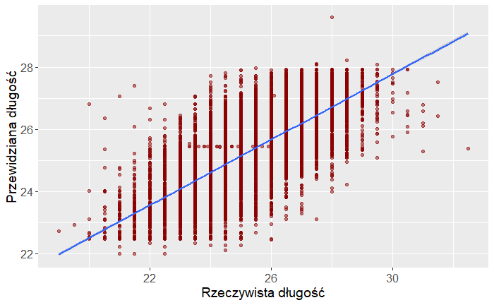

```r
predictionChart(xgbModel)
```

### Ważność parametrów

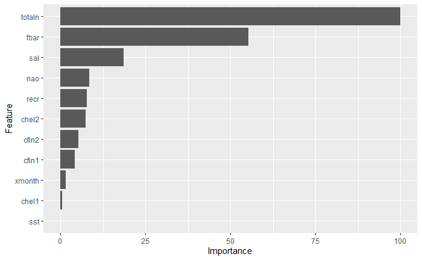

```r
importancePlot(xgbModel)
```

W odróżnieniu od `Random Forest` dla `xgb` najważniejszym parametrem jest wielkość połowu; ma to sens - im większy połów, tym większa stabilizacja rozmiaru śledzia, dąży on do średniej. Z ludzkiego pukntu widzenia również można szukać tutaj zależności - większa ryba, więc jest większa chęć do połowu (mniejszy stosunek pracy do zysku, większa zachęta do sprzedaży; lepiej kupić dużą rybę niż małą). Dalej prawie dwukrotnie mniej ważny okazuje się być `fbar`.

## Extreme Gradien Boosting + preprocessing

```r
xgbPreModel <- train(
  X_train, y_train,
  trControl = trcontrol,
  tuneGrid = xgbGrid,
  method = "xgbTree",
  preProcess = c("center", "scale")
)
```

### Najlepsze parametry

```r
xgbPreModel$bestTune
```

|  | nrounds | max_depth | eta | gamma | colsample_bytree | min_child_weight | subsample |
| --- | --- | --- | --- | --- | --- | --- | --- |
| 1 | 100 | 10 | 0.1 | 0 | 0.5 | 1 | 1 |

### Ewaluacja modelu

Błąd średniokwadratowy dla danych testowych oraz wspołczynnik determinacji

```r
xgbPreStats <- evaluateStats(xgbPreModel)
xgbPreStats
```

```
$RMSE
[1] 1.142

$rSquare
[1] 0.521
```

### Weryfikacja predykcji

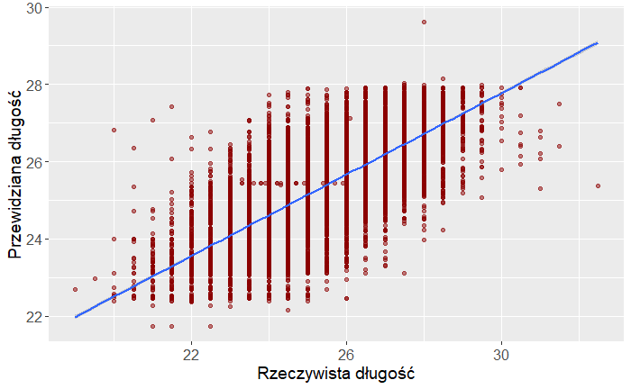

```r
predictionChart(xgbPreModel)
```

### Ważność parametrów

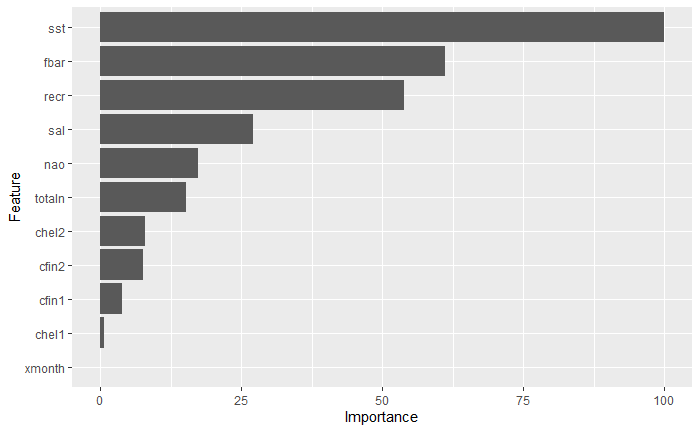

```r
importancePlot(xgbPreModel)
```

Widzimy więc, że skalowanie było w tym wypadku konieczne; dało zupełnie inne wagi parametrów, a przy tym nieznacznie poprawiło predykcję.

# Podsumowanie Regresji

Podsumujmy średnie wyniki

```r
compareDf <- data.frame(t(data.frame(
  knn = unlist(knnStats),
  knnPre = unlist(knnPreStats),
  rf = unlist(rfStats),
  xgb = unlist(xgbStats),
  xgbPre = unlist(xgbPreStats)
)))
compareDf
```

|  | RMSE | rSquare |
| --- | --- | --- |
| knn | 1.148 | 0.516 |
| knnPre | 1.149 | 0.515 |
| rf | 1.150 | 0.514 |
| xgb | 1.143 | 0.520 |
| xgbPre | 1.142 | 0.521 |

Widzimy, że wyniki są bardzo do siebie zbliżone - najbardziej wyróżnia się `xgb`. Możemy również zauważyć, że preprocessing przeprowadzony na `knn` nie przyniósł dużej poprawy; dla `xgb` również nie zwiększył w dużym stopniu miar, jednak całkowicie zmienił ważność parametrów. Analizę ważności parametrów można było zastosować tylko dla `Random Forest` oraz `Extreme Gradient Boosting`; wskazały różne wyniki. Co prawda przedstawialiśmy już macierz korelacji poszczególnych wartości, jednak zwizualizujmy jeszcze średnie przebiegi zmienności wspomnianych parametrów (`xmonth`, `totaln`, `fbar`, `sst` oraz `chel1`).

Analizując wykresy przedstawiające rzeczywiste dane a wynikające z regresji można stwierdzić, że mniej więcej wyniki się zgadzają, jednak przy wartościach z przedziału 18-32 przewidywanie ich zaledwie w zakresie 22-28 przy odchyleniu około 2 nie wydaje się być satysfakcjonujące.

### Analiza zmian wartości wybranych parametrów

Zestawmy zmiany wyżej wspomnianych wartości (pomijając miesiąc ze względu na brak zachowania chronologii) oraz przedstawiających największą korelację (`sst`, `nao`), uwzględniając uśrednione w ciągu przybliżonego roku wartości długości ryby

```r
numericMonthAndYearHerring <- mutate(herringDataWithYearByPeriod, xmonth = as.numeric(xmonth))
baseChart <- meanLengthInYearChart(numericMonthAndYearHerring)

compareWithLengthChange <- function(column, color, fill, coef, offset) {
  meanData <- statsInYear(numericMonthAndYearHerring, column)
  baseChart +
    geom_ribbon(aes(ymin = (meanData$min - offset)/coef, ymax = (meanData$max - offset)/coef), alpha = 0.3, fill = fill, color = "transparent") +
    geom_line(aes(y = (meanData$mean - offset)/coef), color = color, lwd = 0.7) +
    scale_y_continuous(sec.axis = sec_axis(~.*coef + offset, name = column))
}
```

#### Całkowita wielkość połowu (średnia na rok) - `totaln`

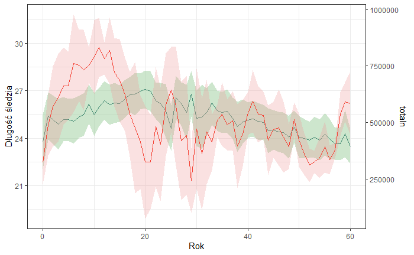

```r
compareWithLengthChange("totaln", "#F44336", "#EF9A9A", 7e4, -1.25e6)
```

Widać, że przez pierwsze ~15 lat połów był największy, jednak długość również rosła. W latach 15-20 połów spadał, natomiast długość dalej rosła. Ciekawa jest zależność wzrostu połowu w latach 20-25, oraz malejąca tendencja w rozmiarze ryby. Patrząc jednak na dalsze lata raczej nie ma powodu by doszukiwać się związku pomiędzy zmianami tych dwóch wartości.

#### Średnie natężenie połowów w rejonie - `fbar`

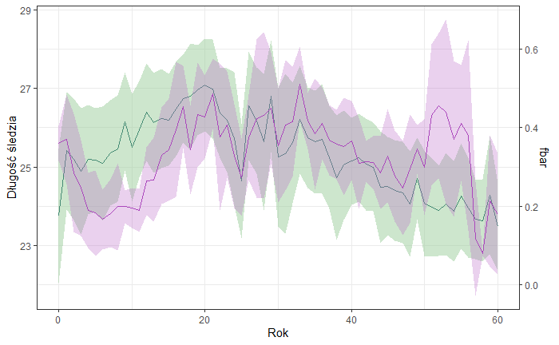

```r
 compareWithLengthChange("fbar", "#AB47BC", "#BA68C8", 1e-1, -2.2)
```

Patrząc na przebieg zmian wartości `fbar` oraz długości śledzia od razu widać zależność; obie wartości rosną od 5-20 roku, później do 25 maleją aby utrzymać podobną tendencję w następnych latach. Zastanawiająca jest jednak rozbieżność w latach 50+, gdzie wzrost wartości `fbar` nie rzutuje na zmianę rozmiaru, choć jego spadek przez ostatnie kilka lat może mieć już na niego wpływ. Możemy więc domniemać o wpływie również innego parametru.

#### Średnia dostępność planktonu *Calanus helgolandicus gat. 1* - `chel1`

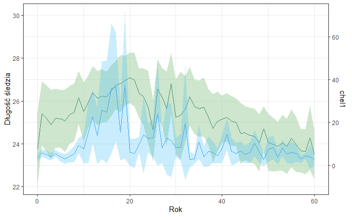

```r
 compareWithLengthChange("chel1", "#42A5F5", "#4FC3F7", 10, -230)
```

Podobnie jak w przypadku parametru `fbar` szybko można dostrzec korelację pomiędzy `chel1` oraz długością ryby. Wydaje się również, że zależność jest nieco przesunięta w czasie, tzn. wpływ zmiany wartości `chel1` widać dopiero po niewielkim upływie czasu w rozmiarze. Widać, że w okresach największej wartości tego parametru, tj. 10-20 lat rozmiar śledzia również był największy, w gwałtownego spadku (lata ~20) rozmiar również zaczął gwałtownie spadać, jednak znacznie wolniej. Przez następne 15 lat nastepowały wahania tego parametru dochodząc jednak do wysokich wartości, jednak po roku 35, gdy zaczał utrzymywać się na niskim poziomie, widać utrzymującą się tendencję spadkową w rozmiarze. Biorąc pod uwagę, że plankton jest pożywieniem śledzia możemy podjąć rozumowanie, że te systematycznie przystosowują się do zaistniałych warunków.

#### Średnia temperatura przy powierzchni wody - `sst`

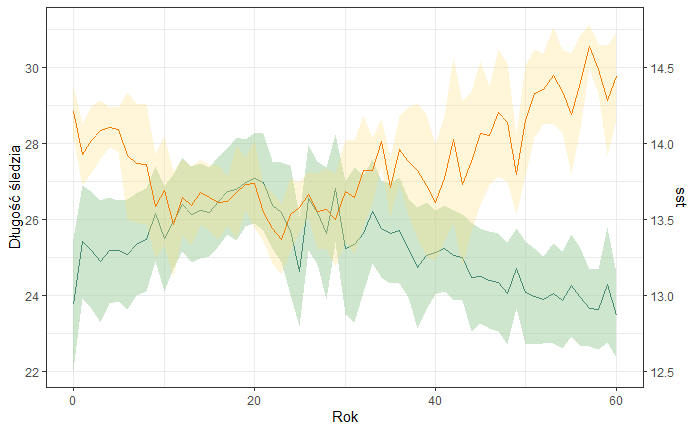

```r
 compareWithLengthChange("sst", "#F57C00", "#FFE082", 1/4, 7)
```

Dla tego parametru widać z kolei ujemną korelację, przy czym wysoką. Widzimy pewne wahania, jednak w ogólności od roku 25 jego wartość rośnie, w przeciwieństwie do rozmiaru ryby.

#### Średnia wartość oscylacji północnoatlantyckiej - `nao`

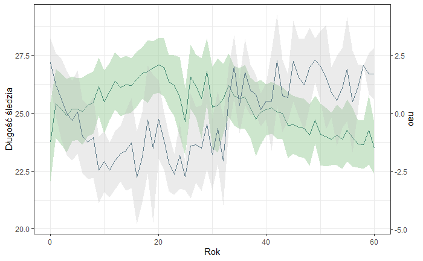

```r
compareWithLengthChange("nao", "#607D8B", "#BDBDBD", 1, -25)
```

Podobnie jak w przypadku wcześniej omawianego parametru widać silną przeciwną korelację, szczególnie mogącą oddziaływać do roku 20, jednak przez ostatnie przez ostatnie lata wartość ta utrzymuje się zgrubsza na podobnym poziomie, przy ciągłym spadku długości śledzia. Możliwe, że mała wartość sprzyja wzrostu (do pewnej wartości), natomiast wysoka w dłuższej perspektywnie negatywnie wpływa na długość.

# Podsumowanie i wnioski

Analiza wartości za pomocą macierzy korelacji okazała się dosyć skuteczna wskazując na ciekawych kandydatów mogących wpływać na zmianę rozmiaru ryby w ostatnich latach. Dzięki niej możemy domniemać o dużym udziale parametrów `sst`, `fbar` oraz `nao` w zmianie rozmiaru ryby. Co więcej, pierwsze dwie z nich zostały również uznane za jedne z najważniejszych przez najlepiej przewidujący regresor *Extreme Gradient Boosting* przy zastosowaniu przetwarzania wstępnego ze skalowaniem i środkowaniem wartości parametrów - ich dziedziny są od siebie bardzo różne. Możemy również domniemać o wpływie `chel1`, jednak obserwacja bazuje jedynie na analizie korelacji zmian obu wartości.

# Źródła

- [Treść zadania](http://www.cs.put.poznan.pl/alabijak/emd/projekt/projekt_analiza.html)
- [Originalne dane](https://github.com/lyashevska/gbrt-herring-length)
- [Create predictive models in R with Caret](https://towardsdatascience.com/create-predictive-models-in-r-with-caret-12baf9941236)
- [Caret Documentation](https://daviddalpiaz.github.io/r4sl/the-caret-package.html)
- [Knn training in R using Caret package](https://dataaspirant.com/2017/01/09/knn-implementation-r-using-caret-package/)
- [Caret practice - Random Forest](https://rpubs.com/phamdinhkhanh/389752)
- [Extreme Gradieng Boosting in Caret](https://datascienceplus.com/extreme-gradient-boosting-with-r/?fbclid=IwAR0Ld3dCvjogSLPw5IH_yV6Ak4h7dWJN37-Ob3IzWW7QzaE-iWrvYZtpvVI)
- [Magic Documentation](https://cran.r-project.org/web/packages/magick/vignettes/intro.html)
- [Plots tutorial in R](https://cedricscherer.netlify.com/2019/08/05/a-ggplot2-tutorial-for-beautiful-plotting-in-r/)
- Niezliczona liczba postów na Stack Overflow